# Lab 13 - Survival analysis

Nonparametric statistics ay 2021/2022

2021/11/19

## Loading necessary libraries

```r
library(survival)
library(survminer)
library(dplyr)
library(ggplot2)
library(knitr)
library(broom)
```

PREPARAZIONE DEL DATASET

```r
setwd("C:/Users/franc/Desktop/NONPA/PROGETTO")

library(stringr)
dataset_old <- read.csv("oasis_longitudinal.csv")
head(dataset_old)
```

|  | Subject.ID | MRI.ID | Group | Visit | MR.Delay | M.F | Hand | Age | EDUC | SES | MMSE | CDR | eTIV | nWBV | ASF |
| --- | --- | --- | --- | --- | --- | --- | --- | --- | --- | --- | --- | --- | --- | --- | --- |
| 1 | OAS2_0001 | OAS2_0001_MR1 | Nondemented | 1 | 0 | M | R | 87 | 14 | 2 | 27 | 0.0 | 1987 | 0.696 | 0.883 |
| 2 | OAS2_0001 | OAS2_0001_MR2 | Nondemented | 2 | 457 | M | R | 88 | 14 | 2 | 30 | 0.0 | 2004 | 0.681 | 0.876 |
| 3 | OAS2_0002 | OAS2_0002_MR1 | Demented | 1 | 0 | M | R | 75 | 12 | NA | 23 | 0.5 | 1678 | 0.736 | 1.046 |
| 4 | OAS2_0002 | OAS2_0002_MR2 | Demented | 2 | 560 | M | R | 76 | 12 | NA | 28 | 0.5 | 1738 | 0.713 | 1.010 |
| 5 | OAS2_0002 | OAS2_0002_MR3 | Demented | 3 | 1895 | M | R | 80 | 12 | NA | 22 | 0.5 | 1698 | 0.701 | 1.034 |
| 6 | OAS2_0004 | OAS2_0004_MR1 | Nondemented | 1 | 0 | F | R | 88 | 18 | 3 | 28 | 0.0 | 1215 | 0.710 | 1.444 |

```r
colnames(dataset_old)
```

```
##  [1] "Subject.ID" "MRI.ID"     "Group"      "Visit"      "MR.Delay"
##  [6] "M.F"        "Hand"       "Age"        "EDUC"       "SES"
## [11] "MMSE"       "CDR"        "eTIV"       "nWBV"       "ASF"
```

```r
## DEMENTI
dataset_old$ID = str_sub(dataset_old$Subject.ID,-3)
dementi_prima <- dataset_old[dataset_old$Group=='Demented'& dataset_old$Visit==1,]
dementi_prima$status <- 1
dementi_prima$group_new <- 'Demented'
##NON DEMENTI
nondementi_last <- dataset_old[dataset_old$Group=='Nondemented',]
nondementi_last <-nondementi_last%>%group_by(ID)%>% mutate(max_visit=max(Visit))%>%ungroup()%>% filter(Visit==max_visit)
length(unique(nondementi_last$ID))
```

```
## [1] 72
```

```r
nondementi_last$status<-0
nondementi_last$group_new <- 'Nondemented'
## CONVERTED

converted_first <- dataset_old[dataset_old$Group=='Converted'&dataset_old$CDR >0,]
converted_first <-converted_first%>%group_by(ID)%>% mutate(min_visit=min(Visit))%>%ungroup()%>% filter(Visit==min_visit)
converted_first$group_new <- 'Demented'
converted_first$status <- 1
#ALL TOGETHER
dataset <- rbind(nondementi_last[,-17],dementi_prima,converted_first[,-17])

dataset$time_y <- dataset$MR.Delay / 365
dataset$status_fact <- factor(dataset$Group)
colnames(dataset) <- c( "Subject.ID",  "MRI.ID"   ,   "Group"   ,    "Visit"   ,    "time" , "M.F"       ,  "Hand" , "age"     ,    "EDUC"   ,     "SES"  ,       "MMSE"     ,   "CDR"     ,    "eTIV"    ,    "nWBV"   ,   "ASF"  ,       "ID"     ,     "status"   ,   "group_new"  , "time_y"    ,  "status_fact")
```

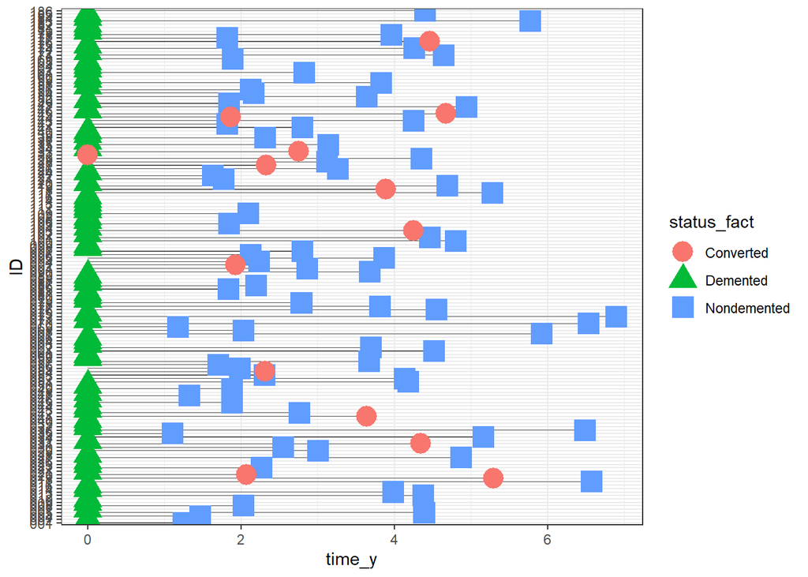

```r
ggplot(data=dataset,aes(x=ID,y=time_y)) +
  geom_bar(stat='identity',width=0.2) +
  geom_point(aes(color=status_fact,shape=status_fact),size=6) +
  coord_flip()
```

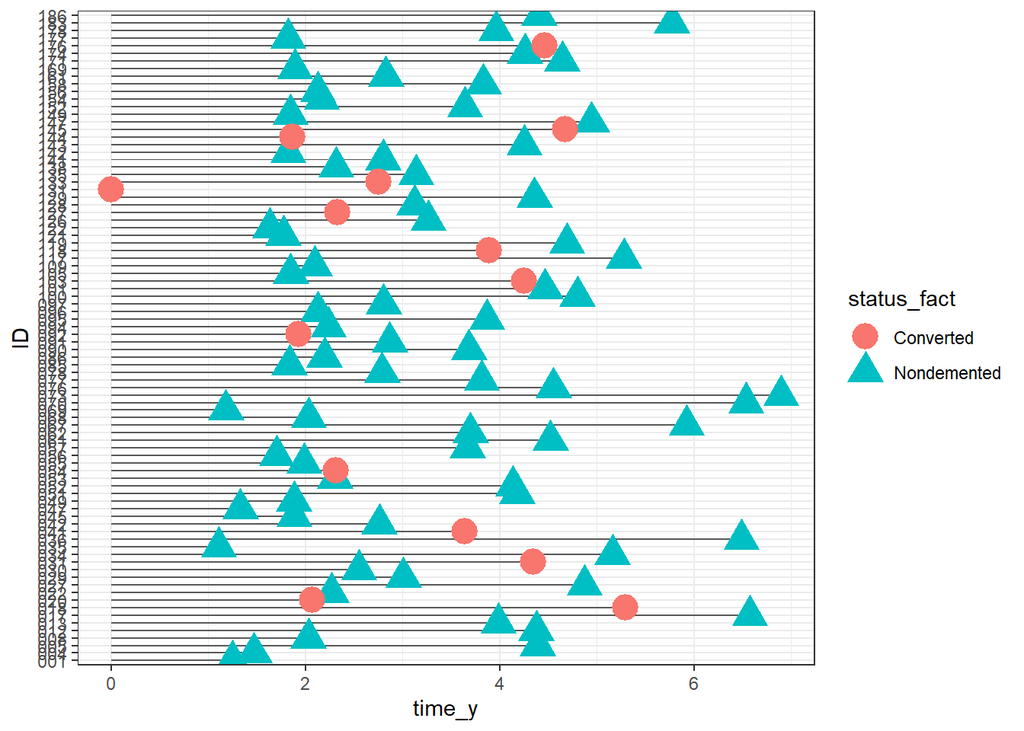

```r
#without demented at first

dataset_nodem <- rbind(nondementi_last[,-17],converted_first[,-17])

dataset_nodem$time_y <- dataset_nodem$MR.Delay / 365
dataset_nodem$status_fact <- factor(dataset_nodem$Group)


ggplot(data=dataset_nodem,aes(x=ID,y=time_y)) +
  geom_bar(stat='identity',width=0.2) +
  geom_point(aes(color=status_fact,shape=status_fact),size=6) +
  coord_flip()
```

Let us investigate the survival probability for all the subjects, by gender and by age.

## Survival Object

The function `Surv(time, event)` of the survival package allows to create a survival object, usually used as a response variable in a model formula. event -> tells me if the event happened or not

```r
head(Surv(dataset$time, dataset$group_new=='Demented'))
```

```
## [1]  457+  538+ 1603+  742+ 1598+ 1456+
```

```r
#Surv(time, event) -> create a surv obj


#457+  538+ 1603+  742+ 1598+ 1456+
# time of death
# for ex 1603+ not censored
```

## Kaplan-Meier estimator for survival curve

( non parametric since we don’t assume a priori any distribution for t) The Kaplan-Meier estimator of a survival curve can be computed using the `survfit` function:

```r
fit <- survfit(Surv(dataset$time, status==1) ~ 1, data = dataset)
# status==1 -> when the event occurred
```

The function survfit() returns a list of variables including the following components:

- n: total number of subjects
- time: the event time points on the curve $(t=t^*_j)$
- n.risk: the number of subjects at risk at time t
- n.event: the number of events that occurred at time t
- n.censor: the number of censored subjects, who exit the risk set at time t
- surv: the kaplan-meier estimator for survival S(t)
- std.err: the standard error for S(t)
- lower, upper: lower and upper confidence limits for the survival curve S(t), respectively.
- cumhaz: the cumulative hazard curve H(t) = - log(S(t))
- std.chaz: the standard error for H(t)

The complete table for Kaplan-Meier estimator can be obtained as follows:

```r
summary(fit)
```

[output not shown]

We make it pretty firstly by tidying the results with the broom package (very useful for a variety of models) and then passing it to the kable function from knitr

```r
kable(head(tidy(fit),20))
```

| time | n.risk | n.event | n.censor | estimate | std.error | conf.high | conf.low |
| --- | --- | --- | --- | --- | --- | --- | --- |
| 0 | 150 | 65 | 0 | 0.5666667 | 0.0714006 | 0.6517844 | 0.4926647 |
| 405 | 85 | 0 | 1 | 0.5666667 | 0.0714006 | 0.6517844 | 0.4926647 |
| 432 | 84 | 0 | 1 | 0.5666667 | 0.0714006 | 0.6517844 | 0.4926647 |
| 457 | 83 | 0 | 1 | 0.5666667 | 0.0714006 | 0.6517844 | 0.4926647 |
| 486 | 82 | 0 | 1 | 0.5666667 | 0.0714006 | 0.6517844 | 0.4926647 |
| 538 | 81 | 0 | 1 | 0.5666667 | 0.0714006 | 0.6517844 | 0.4926647 |
| 597 | 80 | 0 | 1 | 0.5666667 | 0.0714006 | 0.6517844 | 0.4926647 |
| 622 | 79 | 0 | 1 | 0.5666667 | 0.0714006 | 0.6517844 | 0.4926647 |
| 647 | 78 | 0 | 1 | 0.5666667 | 0.0714006 | 0.6517844 | 0.4926647 |
| 665 | 77 | 0 | 2 | 0.5666667 | 0.0714006 | 0.6517844 | 0.4926647 |
| 670 | 75 | 0 | 1 | 0.5666667 | 0.0714006 | 0.6517844 | 0.4926647 |
| 674 | 74 | 0 | 1 | 0.5666667 | 0.0714006 | 0.6517844 | 0.4926647 |
| 675 | 73 | 0 | 1 | 0.5666667 | 0.0714006 | 0.6517844 | 0.4926647 |
| 683 | 72 | 1 | 0 | 0.5587963 | 0.0727575 | 0.6444435 | 0.4845317 |
| 687 | 71 | 0 | 1 | 0.5587963 | 0.0727575 | 0.6444435 | 0.4845317 |
| 689 | 70 | 0 | 1 | 0.5587963 | 0.0727575 | 0.6444435 | 0.4845317 |
| 691 | 69 | 0 | 1 | 0.5587963 | 0.0727575 | 0.6444435 | 0.4845317 |
| 706 | 68 | 1 | 0 | 0.5505787 | 0.0742506 | 0.6368272 | 0.4760112 |
| 726 | 67 | 0 | 1 | 0.5505787 | 0.0742506 | 0.6368272 | 0.4760112 |
| 742 | 66 | 0 | 1 | 0.5505787 | 0.0742506 | 0.6368272 | 0.4760112 |

The median survival times represents the time at which the survival probability, S(t), is 0.5.

```r
surv_median(fit)
```

| strata | median | lower | upper |
| --- | --- | --- | --- |
| All | 1331 | 0 | NA |

```r
# median = 1331 -> median time of death
```

### Kaplan-Meier plots

To plot the KM estimator you can use the function plot

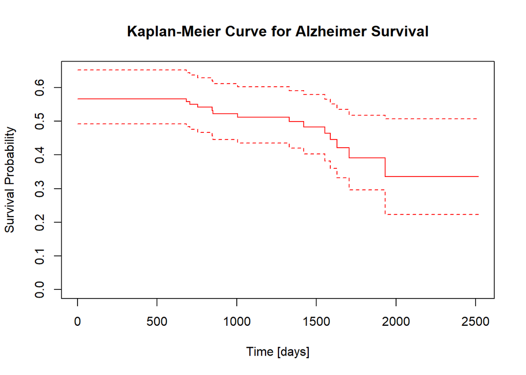

```r
plot(fit, conf.int = T, xlab='Time [days]', ylab = 'Survival Probability', col='red',
     main="Kaplan-Meier Curve for Alzheimer Survival")
```

```r
#survival probability of the patients as time moves on
# if it doesn't reach 0 in the time
# it means that some of the patients are not dead
```

For a better visualization we can use the `ggsurvplot()` function from the survminer package:

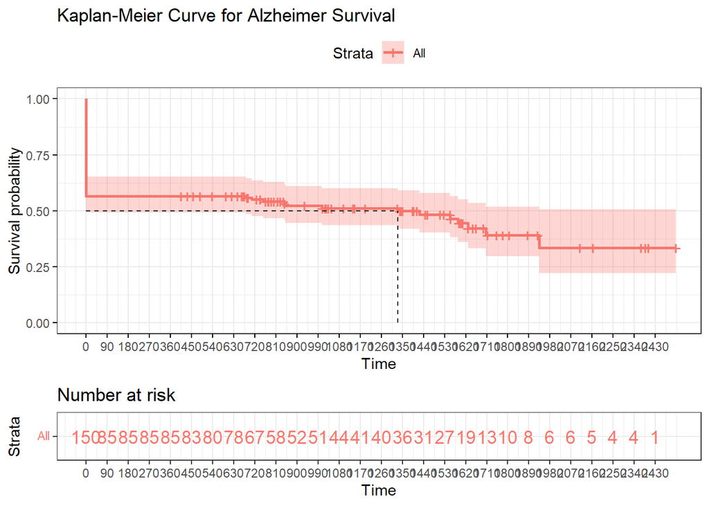

```r
ggsurvplot(fit,
           risk.table = TRUE, # Add risk table
           risk.table.col = "strata", # Change risk table color by groups
           surv.median.line = "hv", # Specify median survival
           ggtheme = theme_bw(), # Change ggplot2 theme
           break.time.by=90,
           title="Kaplan-Meier Curve for Alzheimer Survival")
```

At time zero, the survival probability is 1.0 (or 100% of the participants are alive). At time 540 (after 1 year and 5 months), the probability of survival is approximately 0.55 (or 55%). The median survival is approximately 1331 days. After 1890 days , the survival probability is near 0.35 (35%).

The cumulative incidence, or cumulative failure probability (CFP), (or comulative distribution function), shows the cumulative probabilities of experiencing the event of interest and it is computed as
$$CFP(t) = P(T<t),$$
so it can be estimated as:
$$1-S(t)$$

```r
cumulative_incidence <- 1 - fit$surv
```

We can visualize it using again the `ggsurvplot()` function specifying the option fun=‘event’

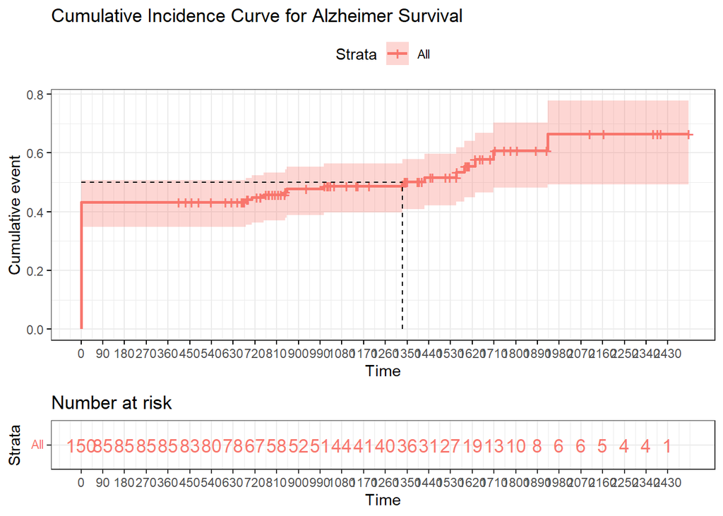

```r
ggsurvplot(fit,
           risk.table = TRUE, # Add risk table
           risk.table.col = "strata", # Change risk table color by groups
           surv.median.line = "hv", # Specify median survival
           ggtheme = theme_bw(), # Change ggplot2 theme
           break.time.by=90,
           fun='event',
           title="Cumulative Incidence Curve for Alzheimer Survival")
```

We may also want to plot the cumulative hazard; it is defined as
$$H(t) = -log(S(t))$$
The cumulative hazard $H(t)$ can be interpreted as the cumulative force of mortality. In other words, it measures the total amount of risk that has been accumulated up to time $t$.

The cumulative hazard is computed by the function `survfit()` using the Nelson-Aalen cumulative hazard rate estimator and it is given by:

```r
H <- fit$cumhaz
```

H is not a probability, it can go over 1 Again we can easily plot it:

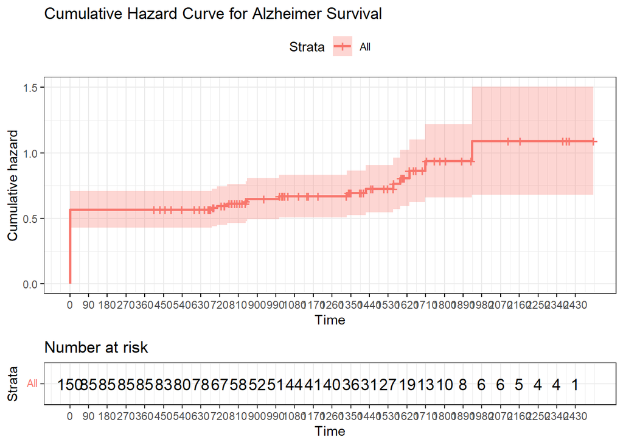

```r
ggsurvplot(fit,
           risk.table = TRUE, # Add risk table
           ggtheme = theme_bw(), # Change ggplot2 theme
           break.time.by=90,
           fun='cumhaz',
           title="Cumulative Hazard Curve for Alzheimer Survival")
```

### Kaplan-Meier Curves between groups

```r
min(dementi_prima$Age) #61
```

```
## [1] 61
```

```r
max(dementi_prima$Age) #96
```

```
## [1] 96
```

```r
min(converted_first$Age) #65
```

```
## [1] 65
```

```r
max(converted_first$Age) #92
```

```
## [1] 92
```

```r
min(nondementi_last$Age) #62
```

```
## [1] 62
```

```r
max(nondementi_last$Age) #97
```

```
## [1] 97
```

```r
min(dataset$age) #61
```

```
## [1] 61
```

```r
max(dataset$age) #97
```

```
## [1] 97
```

```r
fit.age <- survfit(Surv(time, status) ~ age, data=dataset)
#ggsurvplot(fit.age, conf.int = F, risk.table.col = "strata", legend='none')
```

One thing we might do is to categorize a continuous variable into different groups (this clearly works much better for variables that are already categorical, more on this problem later). Let us start by plotting a histogram showing the distribution of age.

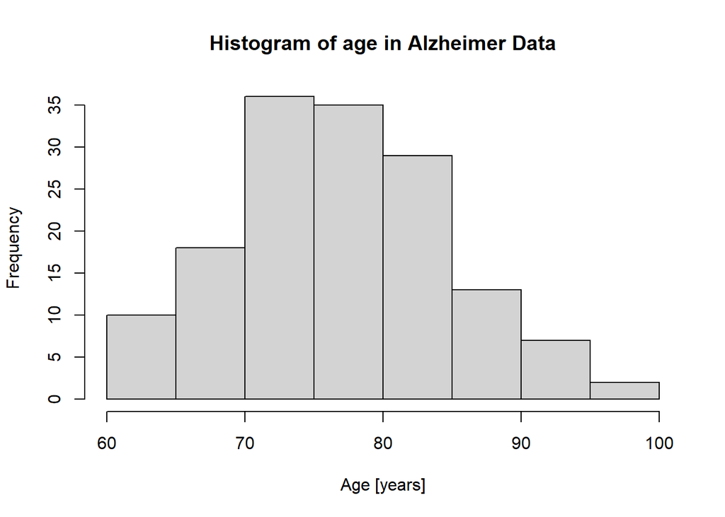

```r
hist(dataset$age, xlab='Age [years]', main='Histogram of age in Alzheimer Data')
```

```r
summary(dataset$age)
```

```
##    Min. 1st Qu.  Median    Mean 3rd Qu.    Max.
##   61.00   72.00   77.00   77.33   82.00   97.00
```

```r
dataset$cutpoint <- cut(dataset$age, breaks=c(60,70,80,90 , Inf), labels=c("60", "70","80","90"))
```

What happens when we make a KM plot with this new categorization?

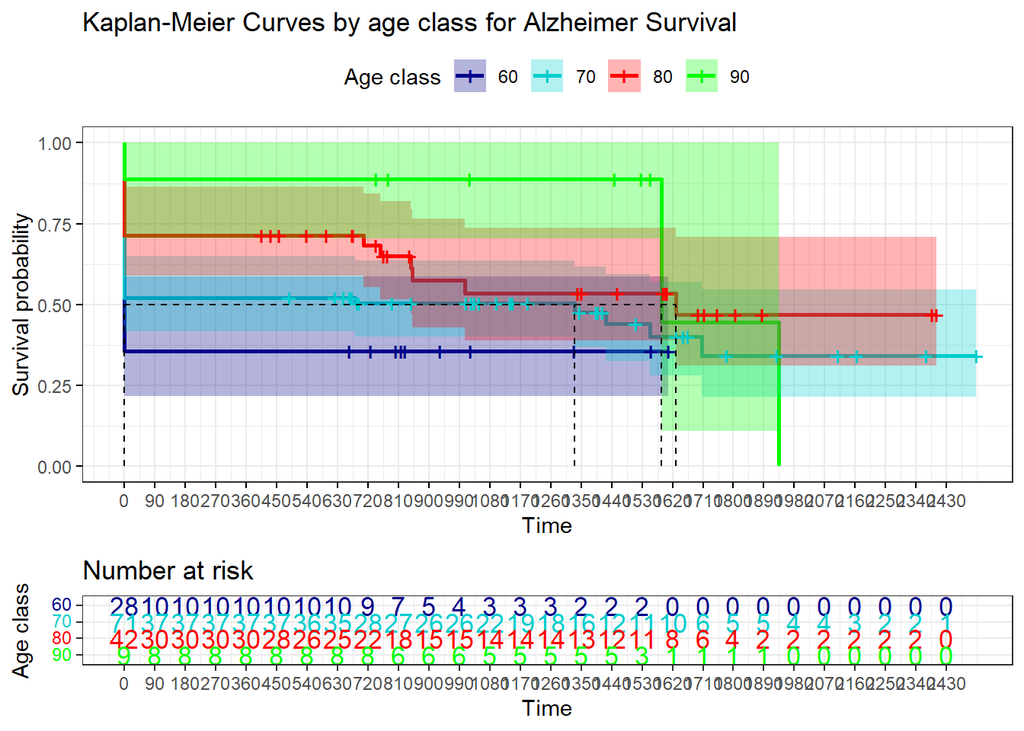

```r
fit.age <- survfit(Surv(time, status) ~ cutpoint, data=dataset)
ggsurvplot(fit.age, conf.int = T,
           risk.table = TRUE, # Add risk table
           risk.table.col = "strata", # Change risk table color by groups
           surv.median.line = "hv", # Specify median survival
           ggtheme = theme_bw(), # Change ggplot2 theme
           break.time.by=90,
           legend.labs=c("60", "70","80","90"), legend.title="Age class",
           palette=c("darkblue","cyan3","red","green"),
           title="Kaplan-Meier Curves by age class for Alzheimer Survival")
```

```r
log_rank_test <- survdiff(Surv(time, status) ~ cutpoint, data=dataset)
log_rank_test  #0.09
```

```
## Call:
## survdiff(formula = Surv(time, status) ~ cutpoint, data = dataset)
##
##              N Observed Expected (O-E)^2/E (O-E)^2/V
## cutpoint=60 28       18    13.01     1.912     3.875
## cutpoint=70 71       39    36.86     0.125     0.369
## cutpoint=80 42       18    22.84     1.026     2.250
## cutpoint=90  9        3     5.29     0.991     1.578
##
##  Chisq= 6.6  on 3 degrees of freedom, p= 0.09
```

```r
#similar to the analysis of variance

# as conseguence of the central limit theroem
# they are asymptotically Gaussian
#if we take the ^2 we can consider them as a X^2 with K-1 df
# X^2(1) since K=2 (n° of groups)
```

## Hazard Ratio

- observed deaths in 60: 18
- expected deaths in 60: 13
- observed deaths in 70: 39
- expected deaths in 70: 36.86
- observed deaths in 80: 18
- expected deaths in 80: 22.84
- observed deaths in 90: 3
- expected deaths in 90: 5.29

Therefore, the death hazard ratio of 60 vs 70 and 60 vs 90:

```r
hazard_ratio <- (log_rank_test$obs[1]/log_rank_test$exp[1])/(log_rank_test$obs[2]/log_rank_test$exp[2])
hazard_ratio #1.30735
```

```
## [1] 1.30735
```

```r
hazard_ratio_14 <- (log_rank_test$obs[1]/log_rank_test$exp[1])/(log_rank_test$obs[4]/log_rank_test$exp[4])
hazard_ratio_14 #2.4392
```

```
## [1] 2.439201
```

HR< 1 -> group 1 protective factor ( less risk) HR= 1 -> similar risk HR> 1 -> group 1 risk factor (more risk)

$HR_{1,2} = 1.30735> 1$

$HR_{1,4} = 2.4392 > 1$ the older you get the less at risk

If we want to investigate the effect of continuous age on survival, without depending on how we categorize the variable, we have to use a survival model, which analyzes the continuous variable over the whole range of its distribution. A survival regression model is asking: “What is the effect of the variable on survival?”.

## Cox model

The Cox proportional-hazards model (Cox, 1972) is essentially a regression model, commonly used in statistical medical research, for investigating the association between the survival time of patients and one or more predictor variables.

it’s called proportional because it doesn’t depend on time

In the previous session, we described the basic concepts of survival analyses and methods for analyzing and summarizing survival data, including:

- the definition of hazard and survival functions,
- the construction of Kaplan-Meier survival curves for different patient groups
- the logrank test for comparing two or more survival curves

The Kaplan-Meier curves and logrank tests are examples of univariate analysis. They describe the survival according to one factor under investigation, but they ignore the impact of any other predictor. Additionally, Kaplan-Meier curves and logrank tests are more useful when the predictor variable is categorical (e.g.: treatment A vs treatment B; males vs females). They do not work easily for quantitative predictors such as gene expression, weight, or age.

An alternative method is the Cox proportional hazards regression analysis, which works for both quantitative predictor variables and for categorical variables. Furthermore, the Cox regression model extends survival analysis methods to assess simultaneously the effect of several risk factors on survival time.

The function `coxph()` in the survival package can be used to compute the Cox proportional-hazards regression model in R.

The simplified format is as follow:

```r
coxph(formula, data, method)
```

where

- formula: linear model with a survival object as the response variable. Survival object is created using the function Surv(time, event)
- data: a data frame containing the variables
- method: is used to specify how to handle ties (we would not deal with this problem here)

Let us consider the continuous variable age and fit a univariate Cox regression model

```r
cox.age <- coxph(Surv(time, status) ~ age, data = dataset)
cox.age
```

```
## Call:
## coxph(formula = Surv(time, status) ~ age, data = dataset)
##
##         coef exp(coef) se(coef)      z      p
## age -0.03777   0.96293  0.01496 -2.524 0.0116
##
## Likelihood ratio test=6.52  on 1 df, p=0.01067
## n= 150, number of events= 78
```

As usual, the function `summary()` produces a more complete report:

```r
summary(cox.age)
```

```
## Call:
## coxph(formula = Surv(time, status) ~ age, data = dataset)
##
##   n= 150, number of events= 78
##
##         coef exp(coef) se(coef)      z Pr(>|z|)
## age -0.03777   0.96293  0.01496 -2.524   0.0116 *
## ---
## Signif. codes:  0 '***' 0.001 '**' 0.01 '*' 0.05 '.' 0.1 ' ' 1
##
##     exp(coef) exp(-coef) lower .95 upper .95
## age    0.9629      1.038    0.9351    0.9916
##
## Concordance= 0.638  (se = 0.042 )
## Likelihood ratio test= 6.52  on 1 df,   p=0.01
## Wald test            = 6.37  on 1 df,   p=0.01
## Score (logrank) test = 6.42  on 1 df,   p=0.01
```

### Visualizing the estimated distribution of survival times

Having fitted a Cox model to the data, it’s possible to visualize the predicted survival proportion at any given point in time for a particular risk group. The function survfit() estimates the survival proportion, by default at the mean values of covariates.

Plot the baseline survival function S_0(t)

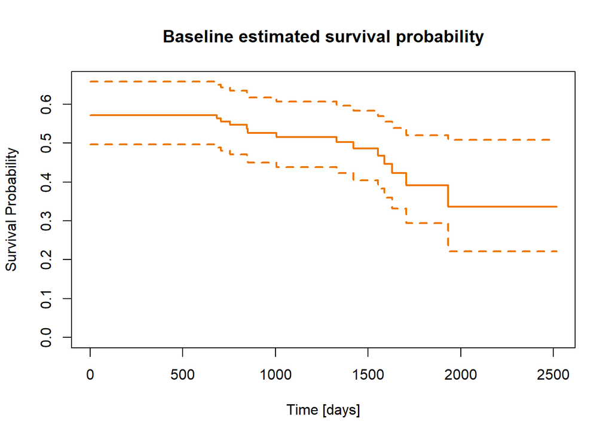

```r
plot(survfit(cox.age, data=dataset),
     col="darkorange2", lwd=2, lty=1,
     xlab='Time [days]', ylab='Survival Probability',
     main='Baseline estimated survival probability')
```

```r
#grid()
```

We may wish to display how estimated survival depends upon the value of the covariates of interest. For istance, we want to assess the impact of the age on the estimated survival probability. In this case, we construct a new data frame with $M$ rows, one for each different value of age we are interested in (usually 2 or 3).

Suppose we want to consider ages equal to 62, 73 and 80. We create the new data:

```r
age_df <- with(dataset,
               data.frame(age = c(62,73,80) )
)
```

This data frame is passed to survfit() via the newdata argument to estimate survival:

```r
fit.age <- survfit(cox.age, newdata = age_df)
fit.age
```

```
## Call: survfit(formula = cox.age, newdata = age_df)
##
##     n events median 0.95LCL 0.95UCL
## 1 150     78      0       0    1588
## 2 150     78    756       0    1631
## 3 150     78   1588     756      NA
```

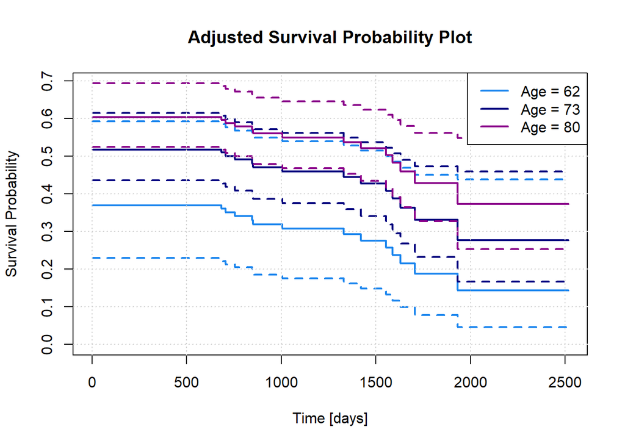

```r
plot(fit.age, conf.int=T,
     col=c("dodgerblue2","navy","darkmagenta"), lwd=2, lty=1,
     xlab='Time [days]', ylab='Survival Probability',
     main='Adjusted Survival Probability Plot')
grid()
legend('topright', c("Age = 62", "Age = 73", "Age = 80"),
       lty=c(1,1,1), lwd=c(2,2,2), col=c("dodgerblue2","navy","darkmagenta"))
```

## Multivariate Cox regression

```r
glimpse(dataset)
```

```
## Rows: 150
## Columns: 21
## $ Subject.ID  <chr> "OAS2_0001", "OAS2_0004", "OAS2_0005", "OAS2_0008", "OAS2_~
## $ MRI.ID      <chr> "OAS2_0001_MR2", "OAS2_0004_MR2", "OAS2_0005_MR3", "OAS2_0~
## $ Group       <chr> "Nondemented", "Nondemented", "Nondemented", "Nondemented"~
## $ Visit       <int> 2, 2, 3, 2, 3, 3, 5, 2, 4, 2, 2, 4, 2, 5, 2, 2, 2, 3, 3, 2~
## $ time        <int> 457, 538, 1603, 742, 1598, 1456, 2400, 828, 1779, 1099, 93~
## $ M.F         <chr> "M", "F", "M", "F", "F", "F", "M", "F", "F", "F", "F", "F"~
## $ Hand        <chr> "R", "R", "R", "R", "R", "R", "R", "R", "R", "R", "R", "R"~
## $ age         <int> 88, 90, 85, 95, 83, 85, 86, 64, 74, 80, 62, 84, 89, 75, 73~
## $ EDUC        <int> 14, 18, 12, 14, 16, 12, 12, 16, 12, 12, 18, 16, 12, 13, 17~
## $ SES         <int> 2, 3, 4, 2, 2, 4, 3, 3, 3, 4, 1, 1, 4, 4, 3, 1, 2, 3, 1, 2~
## $ MMSE        <int> 30, 27, 30, 29, 29, 29, 27, 29, 30, 30, 30, 30, 27, 29, 29~
## $ CDR         <dbl> 0, 0, 0, 0, 0, 0, 0, 0, 0, 0, 0, 0, 0, 0, 0, 0, 0, 0, 0, 0~
## $ eTIV        <int> 2004, 1200, 1699, 1257, 1323, 1225, 1813, 1316, 1353, 1390~
## $ nWBV        <dbl> 0.681, 0.718, 0.705, 0.703, 0.718, 0.710, 0.761, 0.796, 0.~
## $ ASF         <dbl> 0.876, 1.462, 1.033, 1.396, 1.327, 1.433, 0.968, 1.333, 1.~
## $ ID          <chr> "001", "004", "005", "008", "012", "013", "017", "022", "0~
## $ status      <dbl> 0, 0, 0, 0, 0, 0, 0, 0, 0, 0, 0, 0, 0, 0, 0, 0, 0, 0, 0, 0~
## $ group_new   <chr> "Nondemented", "Nondemented", "Nondemented", "Nondemented"~
## $ time_y      <dbl> 1.252055, 1.473973, 4.391781, 2.032877, 4.378082, 3.989041~
## $ status_fact <fct> Nondemented, Nondemented, Nondemented, Nondemented, Nondem~
## $ cutpoint    <fct> 80, 80, 80, 90, 80, 80, 80, 60, 70, 70, 60, 80, 80, 70, 70~
```

```r
dataset$sex <- as.factor(dataset$M.F)
```

Fit the Cox’s regression model:

```r
mod.cox <- coxph(Surv(time, status) ~ age + sex + EDUC + MMSE, data =  dataset)
summary(mod.cox)
```

```
## Call:
## coxph(formula = Surv(time, status) ~ age + sex + EDUC + MMSE,
##     data = dataset)
##
##   n= 150, number of events= 78
##
##          coef exp(coef) se(coef)      z Pr(>|z|)
## age  -0.01958   0.98061  0.01530 -1.280    0.201
## sexM  0.33560   1.39878  0.23856  1.407    0.159
## EDUC -0.06832   0.93396  0.04308 -1.586    0.113
## MMSE -0.22822   0.79595  0.03415 -6.683 2.34e-11 ***
## ---
## Signif. codes:  0 '***' 0.001 '**' 0.01 '*' 0.05 '.' 0.1 ' ' 1
##
##      exp(coef) exp(-coef) lower .95 upper .95
## age     0.9806     1.0198    0.9516     1.010
## sexM    1.3988     0.7149    0.8764     2.233
## EDUC    0.9340     1.0707    0.8583     1.016
## MMSE    0.7959     1.2564    0.7444     0.851
##
## Concordance= 0.895  (se = 0.022 )
## Likelihood ratio test= 62.56  on 4 df,   p=8e-13
## Wald test            = 78.68  on 4 df,   p=3e-16
## Score (logrank) test = 92.39  on 4 df,   p=<2e-16
```

### Visualizing Hazard ratios

You can visualize Hr and its CIs using the `ggforest()` function of package survminer:

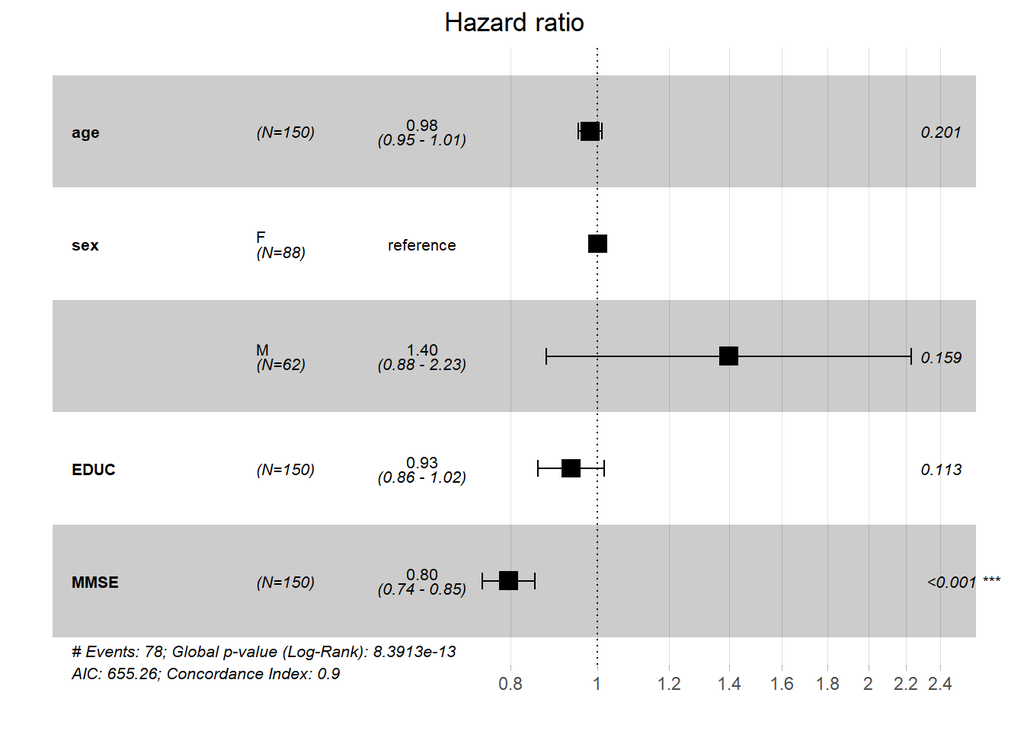

```r
ggforest(mod.cox, data=dataset)
```

Because the confidence interval for HR includes 1, these results indicate that age makes a smaller contribution to the difference in the HR after adjusting for the other covariates.

Plot the baseline survival function $S_0(t)$

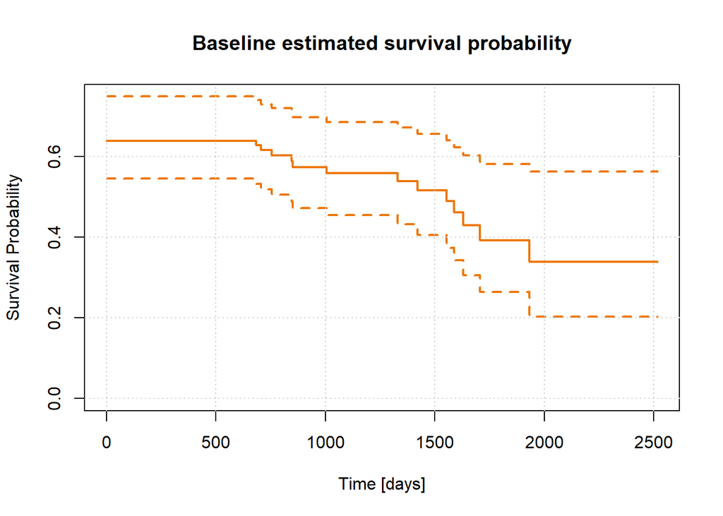

```r
plot(survfit(mod.cox, data=dataset),
     col="darkorange2", lwd=2, lty=1,
     xlab='Time [days]', ylab='Survival Probability',
     main='Baseline estimated survival probability')
grid()
```

```r
mod.cox_age_sex <- coxph(Surv(time, status) ~ age + sex , data =  dataset)
summary(mod.cox_age_sex)
```

```
## Call:
## coxph(formula = Surv(time, status) ~ age + sex, data = dataset)
##
##   n= 150, number of events= 78
##
##          coef exp(coef) se(coef)      z Pr(>|z|)
## age  -0.03664   0.96402  0.01514 -2.419   0.0155 *
## sexM  0.58069   1.78727  0.22736  2.554   0.0106 *
## ---
## Signif. codes:  0 '***' 0.001 '**' 0.01 '*' 0.05 '.' 0.1 ' ' 1
##
##      exp(coef) exp(-coef) lower .95 upper .95
## age      0.964     1.0373    0.9358    0.9931
## sexM     1.787     0.5595    1.1446    2.7908
##
## Concordance= 0.679  (se = 0.04 )
## Likelihood ratio test= 12.99  on 2 df,   p=0.002
## Wald test            = 12.75  on 2 df,   p=0.002
## Score (logrank) test = 12.98  on 2 df,   p=0.002
```

```r
mod.cox_MMSE <- coxph(Surv(time, status) ~ MMSE , data =  dataset)
summary(mod.cox_MMSE)
```

```
## Call:
## coxph(formula = Surv(time, status) ~ MMSE, data = dataset)
##
##   n= 150, number of events= 78
##
##          coef exp(coef) se(coef)      z Pr(>|z|)
## MMSE -0.26320   0.76859  0.03146 -8.365   <2e-16 ***
## ---
## Signif. codes:  0 '***' 0.001 '**' 0.01 '*' 0.05 '.' 0.1 ' ' 1
##
##      exp(coef) exp(-coef) lower .95 upper .95
## MMSE    0.7686      1.301    0.7226    0.8175
##
## Concordance= 0.827  (se = 0.033 )
## Likelihood ratio test= 56.51  on 1 df,   p=6e-14
## Wald test            = 69.98  on 1 df,   p=<2e-16
## Score (logrank) test = 84.26  on 1 df,   p=<2e-16
```

```r
mod.cox_ALL <- coxph(Surv(time, status) ~ age + sex + EDUC + MMSE+ SES + eTIV, data =  dataset)
summary(mod.cox_ALL)
```

```
## Call:
## coxph(formula = Surv(time, status) ~ age + sex + EDUC + MMSE +
##     SES + eTIV, data = dataset)
##
##   n= 142, number of events= 70
##    (8 observations deleted due to missingness)
##
##           coef exp(coef)  se(coef)      z Pr(>|z|)
## age  -0.021445  0.978783  0.015662 -1.369   0.1709
## sexM  0.644026  1.904132  0.306566  2.101   0.0357 *
## EDUC -0.117783  0.888889  0.066022 -1.784   0.0744 .
## MMSE -0.237365  0.788704  0.035073 -6.768 1.31e-11 ***
## SES  -0.273754  0.760519  0.156395 -1.750   0.0801 .
## eTIV -0.001279  0.998722  0.000917 -1.395   0.1631
## ---
## Signif. codes:  0 '***' 0.001 '**' 0.01 '*' 0.05 '.' 0.1 ' ' 1
##
##      exp(coef) exp(-coef) lower .95 upper .95
## age     0.9788     1.0217    0.9492    1.0093
## sexM    1.9041     0.5252    1.0441    3.4725
## EDUC    0.8889     1.1250    0.7810    1.0117
## MMSE    0.7887     1.2679    0.7363    0.8448
## SES     0.7605     1.3149    0.5597    1.0333
## eTIV    0.9987     1.0013    0.9969    1.0005
##
## Concordance= 0.908  (se = 0.021 )
## Likelihood ratio test= 64.55  on 6 df,   p=5e-12
## Wald test            = 79.21  on 6 df,   p=5e-15
## Score (logrank) test = 96.64  on 6 df,   p=<2e-16
```

alla fine il più significativo è sempre MMSE